# Практикум_1

## Практикум 1

# Саенко Анастасия

Загрузим необходимые библиотеки

```r
library(haven)
library(dplyr)
library(ggplot2)
library(margins)
library(psych)
library(memisc)
```

Загрузим данные

```r
df <- read_dta('./tvims3_lab1_2.dta')
```

## Задание 1.

```r
ml1 <- lm(wbge ~ fhpolity+lngdppc+fhpolity:lngdppc, data =df)
summary(ml1)
```

```
##
## Call:
## lm(formula = wbge ~ fhpolity + lngdppc + fhpolity:lngdppc, data = df)
##
## Residuals:
##      Min       1Q   Median       3Q      Max
## -1.25511 -0.29618 -0.04548  0.35566  1.83784
##
## Coefficients:
##                  Estimate Std. Error t value Pr(>|t|)
## (Intercept)      -2.32032    0.63434  -3.658  0.00035 ***
## fhpolity         -0.42174    0.10340  -4.079 7.29e-05 ***
## lngdppc           0.18247    0.07586   2.405  0.01736 *
## fhpolity:lngdppc  0.06088    0.01164   5.229 5.55e-07 ***
## ---
## Signif. codes:  0 '***' 0.001 '**' 0.01 '*' 0.05 '.' 0.1 ' ' 1
##
## Residual standard error: 0.4987 on 152 degrees of freedom
## Multiple R-squared:  0.7566, Adjusted R-squared:  0.7518
## F-statistic: 157.5 on 3 and 152 DF,  p-value: < 2.2e-16
```

**Интерпретация оценок коэффициентов при всех предикторах**: Из выдачи можно увидеть, что все коэффициенты значимы на уровне значимости 0.001 ( кроме lngdppc, который значим на уровне 0.05).

1)Значение константы равное -2.32 - среднее значение зависимой переменной( то есть эффективности государственного управления) при условии того, что все предикторы в модели равны 0 и переменная взамодействия также 0.

2. Предиктор -0.42 (fhpolity) - при увеличении fhpolity на единицу измерения зависимиая переменная ( эффективность управления) в среднем уменьшается на 0.42 при условии того, что ввп - 0.
3. lngdppc 0.18247 - на 0.18 в среднем эффективность гос.управления, когда ввп =1,больше по сравнению с тем, где оно 0 при условии того, что fhpolity =0.( или при переходе ввп от 0 к 1 в среднем зависимая переменная увеличивается на 0.18 при условии, что fhpolity =0)
4. Переменная взамодействия - при переходе ввп от 0 к 1 в среднем взаимосвязь зависимой переменной и fhpolity увеличивается на 0.06.

## Задание 2

1. Преобразуем шкалу переменной логарифма ВВП(lngdppc) так, чтобы она включала значение 0. Преобразуем с помощью центрирования.

```r
df$scaledlng <- df$lngdppc - mean(df$lngdppc)
```

Оценим вторую регрессионную модель с преобразованной переменной.

```r
ml2 <- lm(wbge ~ fhpolity+scaledlng+fhpolity:scaledlng, data =df)
mtable(ml1,ml2)
```

```
##
## Calls:
## ml1: lm(formula = wbge ~ fhpolity + lngdppc + fhpolity:lngdppc, data = df)
## ml2: lm(formula = wbge ~ fhpolity + scaledlng + fhpolity:scaledlng,
##     data = df)
##
## ================================================
##                            ml1         ml2
## ------------------------------------------------
##   (Intercept)            -2.320***   -0.779***
##                          (0.634)     (0.096)
##   fhpolity               -0.422***    0.093***
##                          (0.103)     (0.015)
##   lngdppc                 0.182*
##                          (0.076)
##   fhpolity x lngdppc      0.061***
##                          (0.012)
##   scaledlng                           0.182*
##                                      (0.076)
##   fhpolity x scaledlng                0.061***
##                                      (0.012)
## ------------------------------------------------
##   R-squared               0.757       0.757
##   N                     156         156
## ================================================
##   Significance: *** = p < 0.001;
##                 ** = p < 0.01; * = p < 0.05
```

Прим : так как был создан новый столбец, в таблице немного сместились показатели, но это не мешает провести интерпретацию ( scaledlng это новая переменная lngdppc)

Изменится интерпретация константы: -0.779 - среднее значение эффективности госуправления ( зависимой переменной ) при условии что центированный показатель ввп равен 0 и fhpolity также 0.

Изменится при предикторе fhpolity : при увеличении демократии на единицу измерения и при условии, что центированный показатель ввп равен 0 эффективность гос.управления в среднем увеличится на 0.09

Остальное совпадает.

## Задание 3

Предельные эффекты ( по ml1)

```r
s2 <- margins(ml1, at = list(fhpolity = 0:10))
summary(s2)
```

```
##    factor fhpolity    AME     SE       z      p  lower  upper
##  fhpolity   0.0000 0.0927 0.0147  6.3018 0.0000 0.0639 0.1215
##  fhpolity   1.0000 0.0927 0.0147  6.3015 0.0000 0.0639 0.1215
##  fhpolity   2.0000 0.0927 0.0147  6.3016 0.0000 0.0639 0.1215
##  fhpolity   3.0000 0.0927 0.0147  6.3018 0.0000 0.0639 0.1215
##  fhpolity   4.0000 0.0927 0.0147  6.3017 0.0000 0.0639 0.1215
##  fhpolity   5.0000 0.0927 0.0147  6.3019 0.0000 0.0639 0.1215
##  fhpolity   6.0000 0.0927 0.0147  6.3017 0.0000 0.0639 0.1215
##  fhpolity   7.0000 0.0927 0.0147  6.3018 0.0000 0.0639 0.1215
##  fhpolity   8.0000 0.0927 0.0147  6.3018 0.0000 0.0639 0.1215
##  fhpolity   9.0000 0.0927 0.0147  6.3018 0.0000 0.0639 0.1215
##  fhpolity  10.0000 0.0927 0.0147  6.3018 0.0000 0.0639 0.1215
##   lngdppc   0.0000 0.1825 0.0759  2.4053 0.0162 0.0338 0.3311
##   lngdppc   1.0000 0.2434 0.0660  3.6869 0.0002 0.1140 0.3727
##   lngdppc   2.0000 0.3042 0.0568  5.3533 0.0000 0.1928 0.4156
##   lngdppc   3.0000 0.3651 0.0487  7.4935 0.0000 0.2696 0.4606
##   lngdppc   4.0000 0.4260 0.0423 10.0703 0.0000 0.3431 0.5089
##   lngdppc   5.0000 0.4869 0.0384 12.6727 0.0000 0.4116 0.5622
##   lngdppc   6.0000 0.5478 0.0379 14.4661 0.0000 0.4736 0.6220
##   lngdppc   7.0000 0.6087 0.0408 14.9269 0.0000 0.5287 0.6886
##   lngdppc   8.0000 0.6695 0.0465 14.3974 0.0000 0.5784 0.7607
##   lngdppc   9.0000 0.7304 0.0542 13.4854 0.0000 0.6243 0.8366
##   lngdppc  10.0000 0.7913 0.0631 12.5494 0.0000 0.6677 0.9149
```

Первое, что можно заметить - AME показывает, что переменные оказывают 1) положительный эффект на на зависимую переменную 2) этот эффект значимый ( все p-value достаточно низкие) 3) доверительные интервалы не накрывают 0 - что тоже говорит о значимости

Говоря о изменении предельного эффекта с ростом уровня демократии можно заметить, что он стабильно растет по lngdppc, то есть эффект независимой переменной ввп на эффективность гос.управления растет с увеличением уровня демократии.

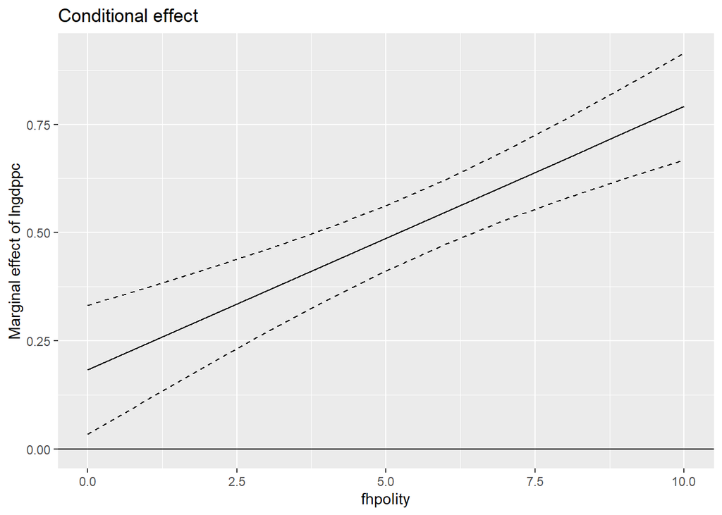

```r
ggplot(s2, aes(x = fhpolity)) +
  geom_line(aes(y = dydx_lngdppc)) +
  geom_line(aes(y = dydx_lngdppc+1.96*sqrt(Var_dydx_lngdppc)), linetype = 2) +
  geom_line(aes(y = dydx_lngdppc-1.96*sqrt(Var_dydx_lngdppc)), linetype = 2) +
  geom_hline(yintercept = 0) +
  ggtitle("Conditional effect") +
  xlab("fhpolity") + ylab("Marginal effect of lngdppc")
```

## Задание 4

Примечание - оставили центрированный ввп, так как это было сделано на прошлом шаге.

```r
ml3 <- lm(wbge ~dembinary+scaledlng + dembinary:scaledlng, data = df)
summary(ml3)
```

```
##
## Call:
## lm(formula = wbge ~ dembinary + scaledlng + dembinary:scaledlng,
##     data = df)
##
## Residuals:
##      Min       1Q   Median       3Q      Max
## -1.31992 -0.32893 -0.06789  0.39231  1.80160
##
## Coefficients:
##                     Estimate Std. Error t value Pr(>|t|)
## (Intercept)         -0.42193    0.07105  -5.939 1.88e-08 ***
## dembinary            0.41609    0.09487   4.386 2.15e-05 ***
## scaledlng            0.37826    0.05878   6.436 1.52e-09 ***
## dembinary:scaledlng  0.42344    0.08008   5.288 4.24e-07 ***
## ---
## Signif. codes:  0 '***' 0.001 '**' 0.01 '*' 0.05 '.' 0.1 ' ' 1
##
## Residual standard error: 0.5557 on 152 degrees of freedom
## Multiple R-squared:  0.6977, Adjusted R-squared:  0.6917
## F-statistic: 116.9 on 3 and 152 DF,  p-value: < 2.2e-16
```

Рассчитайте и проинтерпретируйте предсказанные значения эффективности государственного управления при максимальном значении логарифма ВВП на душу населения в демократических и недемократических политических режимах.

Значение с max ввп при демократии ( dembinary =1)

```r
max(df$scaledlng)
```

```
## [1] 1.992882
```

```r
-0.42193+ 0.41609 +0.37826*max(df$scaledlng)+0.42344*max(df$scaledlng)
```

```
## [1] 1.591854
```

Значение с max ввп без демократии ( dembinary =0)

```r
-0.42193 +0.37826*max(df$scaledlng)
```

```
## [1] 0.3318976
```

Как мы можем увидеть показатель эффективности государственного управления значительно выше там, где есть демократия при максимальном уровне ввп, чем там где демократии нет.

## Задание 5

Сравним модель ml3 ( с переменной взаимодействия) и модели на отдельных выборках в зависимости от значения модератора.

```r
interactions1 <- subset(df, dembinary == 1)
m2_1 <- lm(wbge ~ scaledlng, data = interactions1)


interactions0 <- subset(df, dembinary == 0)
m2_2 <- lm(wbge ~ scaledlng, data = interactions0)


mtable(ml3, m2_1, m2_2)
```

```
##
## Calls:
## ml3: lm(formula = wbge ~ dembinary + scaledlng + dembinary:scaledlng,
##     data = df)
## m2_1: lm(formula = wbge ~ scaledlng, data = interactions1)
## m2_2: lm(formula = wbge ~ scaledlng, data = interactions0)
##
## ===========================================================
##                             ml3        m2_1       m2_2
## -----------------------------------------------------------
##   (Intercept)             -0.422***  -0.006     -0.422***
##                           (0.071)    (0.057)    (0.079)
##   dembinary                0.416***
##                           (0.095)
##   scaledlng                0.378***   0.802***   0.378***
##                           (0.059)    (0.049)    (0.065)
##   dembinary x scaledlng    0.423***
##                           (0.080)
## -----------------------------------------------------------
##   R-squared                0.698      0.761      0.331
##   N                      156         86         70
## ===========================================================
##   Significance: *** = p < 0.001; ** = p < 0.01;
##                 * = p < 0.05
```

Оценка константы в подвыборке, где dembinary = 1,-0.006(при это оценка стала незначимой), оценка при предикторе -0.802. В моделе, где dembinary =0 : константа и оценка коэффициента при предикторе совпадают.

**Как можно получить оценки коэффициентов из оценок модели ml3:**

Оценка константы(m2_1) = константа ml3 +dembinary ml3

Коэффициент при предикторе (m2_1 ) = оценка предиктора в ml3 + оценка переменной взаимодействия( dembinary x lngdppc)